# 2026/7/30 笔记

[figure not shown]

Transformer整体架构

[figure not shown]

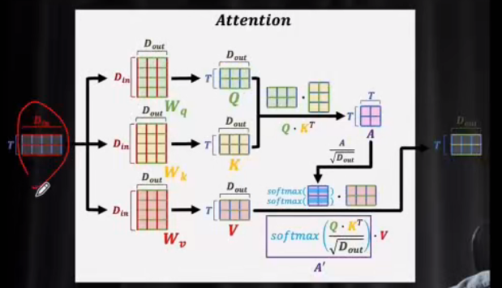

注意力机制计算过程

$$ Attention(Q,K,V) = softmax(\frac{QK^T}{\sqrt{d_k}})V $$

- attention计算过程中的QKV点乘运算主要目的就是:  
  用于计算Query和Key之间的相关性，通过这个相关性得到注意力权重，然后利用权重对Value进行加权求和，  
  使当前位置的词向量融合上下文信息。这个过程不是直接改变QKV的方向，而是在新的语义空间中动态调整  
  不同词信息的贡献比例，从而生成包含上下文信息的表示。
- 更好理解**加权求和**：

[figure not shown]

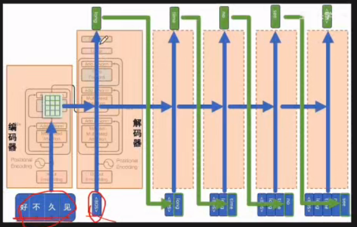

- Encoder-Decoder架构常用于机器翻译： 将输入的中文翻译成英文  
  encoder部分将中文进行嵌入、编码，再经过不同的映射后作为decoder部分的K、V矩阵（这个做法也比较合理，因为是通过对V矩阵进行加权来得到下面的翻译结果）。
  - 在解码器部分输入第一个token是`<BOS>`用于表示开始字符
  - 解码器中先进行自注意力计算，然后与编码器结果进行交叉注意力计算
  - 每一步预测出的 Token 会作为下一步 Decoder 的输入：`<BOS>` -> `<BOS>` Long -> `<BOS>` Long time -> `<BOS>` Long time no -> `<BOS>` Long time no see

# 2026/7/31

- Add & Norm 中使用残差链接的原因：
  - 注意力层或前馈层并不一定总能产生更好的表示，尤其是在网络层数很深的时候注意力层的结果可能起到反效果，  
    因此为了防止经过该层的张量的表征能力变差，于是在此加上原有的张量这样至少能保证原有张量的能力，不会起到反效果。
  - 关于梯度消失：大模型的层数非常多，梯度回传要经过很多层，最后导致梯度消失。添加残差连接可以使梯度  
    相对直接回传到前面的层，从而使训练相对快速稳定。
- LayerNorm 过程：针对每个token，分别进行**减均值，除方差**操作
  例如残差链接的结果$X$的张量形状为`(batch, seq_len, hidden_dim) -> (1, 4, 5)`，
  代表共有4个token，每个token维度为5。
  $$ X= \begin{bmatrix} x_{11}&x_{12}&x_{13}&x_{14}&x_{15}\\ x_{21}&x_{22}&x_{23}&x_{24}&x_{25}\\ x_{31}&x_{32}&x_{33}&x_{34}&x_{35}\\ x_{41}&x_{42}&x_{43}&x_{44}&x_{45} \end{bmatrix} $$ 均值： $$ \mu=\frac{x_{11}+x_{12}+x_{13}+x_{14}+x_{15}}{5} $$ 方差： $$ \sigma^2=\frac{\sum(x_{1i}-\mu)^2}{5} $$ 正则化结果： $$ \hat{x_{1i}}=\gamma\cdot\frac{x_{1i}-\mu}{\sqrt{\sigma^2+\epsilon}}+\beta $$ 注意：
  - 沿**隐藏层维度**进行归一化，即对每个 token 独立计算其特征维度的均值和方差，不是在不同 token 之间进行归一化。
  - LayerNorm也有**可学习的参数**，并不只是单纯数学处理：**$\gamma$权重 $\beta$偏置**
- Feed Forward Net(FFN)过程：
  $$ FFN(x)=max(0,xW_1+b_1)W_2+b_2 $$ $W_1$升维度、$W_2$降维度:
  $$ d_{model}=512 \rightarrow d_{ff}=2048 \rightarrow d_{model}=512 $$ 目的：**引入非线性变换的同时增加特征表示能力**
- Dropout细节：
  - Pytorch中Dropout(0.1)代表将输入张量中随机10%的数值置零
  - 其余数值按照比例放大：
    $$\frac{1}{1-p}$$ 其中，$p$是dropout概率。这一步的目的是为了保证输出的期望值（平均值）不变。

多头注意力手撕

```python
import torch
import torch.nn as nn
import math

class ScaledDotProductAttention(nn.Module):
    """
    论文公式: Attention(Q, K, V) = softmax(QK^T / sqrt(d_k)) V
    纯 PyTorch 原生实现，无第三方封装
    """
    def __init__(self, d_k):
        super().__init__()
        self.d_k = d_k

    def forward(self, q, k, v, mask=None):
        # 1. 计算注意力分数: Q @ K^T
        # q: [batch, heads, seq_len, d_k]
        # k: [batch, heads, seq_len, d_k]
        scores = torch.matmul(q, k.transpose(-2, -1)) / math.sqrt(self.d_k)

        # 2. Mask 处理 (防止信息泄露 / Padding 屏蔽)
        if mask is not None:
            scores = scores.masked_fill(mask == 0, -1e9)

        # 3. Softmax 归一化
        attn_weights = torch.softmax(scores, dim=-1)

        # 4. 加权求和: attn_weights @ V
        output = torch.matmul(attn_weights, v)
        return output, attn_weights

class MultiHeadAttention(nn.Module):
    """
    多头注意力机制
    论文公式: MultiHead(Q,K,V) = Concat(head_1, ..., head_h) W^O
    """
    def __init__(self, d_model, num_heads):
        super().__init__()
        assert d_model % num_heads == 0, "d_model must be divisible by num_heads"

        self.d_model = d_model
        self.num_heads = num_heads
        self.d_k = d_model // num_heads

        # 线性投影层 (W_Q, W_K, W_V, W_O)
        self.w_q = nn.Linear(d_model, d_model)
        self.w_k = nn.Linear(d_model, d_model)
        self.w_v = nn.Linear(d_model, d_model)
        self.w_o = nn.Linear(d_model, d_model)

        self.attention = ScaledDotProductAttention(self.d_k)

    def forward(self, query, key, value, mask=None):
        batch_size = query.size(0)

        # 1. 线性投影并分头: [batch, seq, d_model] -> [batch, heads, seq, d_k]
        # 将 d_model 按照注意力头数均分隐藏层维度
        # 转置的目的是让 序列长度 和 隐藏维度数 放在最后两个维度位置上，便于矩阵乘法
        q = self.w_q(query).view(batch_size, -1, self.num_heads, self.d_k).transpose(1, 2)
        k = self.w_k(key).view(batch_size, -1, self.num_heads, self.d_k).transpose(1, 2)
        v = self.w_v(value).view(batch_size, -1, self.num_heads, self.d_k).transpose(1, 2)

        # 2. 缩放点积注意力
        attn_output, attn_weights = self.attention(q, k, v, mask)

        # 3. 多头拼接 + 最终线性投影
        # [batch, heads, seq, d_k] -> [batch, seq, d_model]
        attn_output = attn_output.transpose(1, 2).contiguous().view(batch_size, -1, self.d_model)
        output = self.w_o(attn_output)

        return output, attn_weights

# --- 验证代码 (他可以直接跑这段来测试) ---
if __name__ == "__main__":
    # 模拟输入: batch=2, seq_len=5, d_model=64, heads=8
    batch_size, seq_len, d_model, num_heads = 2, 5, 64, 8
    d_k = d_model // num_heads

    # 随机生成 Q, K, V
    query = torch.randn(batch_size, seq_len, d_model)
    key = torch.randn(batch_size, seq_len, d_model)
    value = torch.randn(batch_size, seq_len, d_model)

    # 初始化多头注意力
    mha = MultiHeadAttention(d_model, num_heads)

    # 计算掩码矩阵
    # tril生成下三角矩阵
    mask = torch.tril(torch.ones(seq_len, seq_len))

    # 前向传播
    output, weights = mha(query, key, value, mask)

    print(f"输入维度: {query.shape}")
    print(f"输出维度: {output.shape}")  # 应为 [2, 5, 64]
    print(f"注意力权重维度: {weights.shape}")  # 应为 [2, 8, 5, 5]
    print("✅ 核心公式验证通过，维度对齐无误")
```

```
输入维度: torch.Size([2, 5, 64])
输出维度: torch.Size([2, 5, 64])
注意力权重维度: torch.Size([2, 8, 5, 5])
✅ 核心公式验证通过，维度对齐无误
```

TransformerEncoder手撕

```python
class EncoderLayer(nn.Module):
    def __init__(self, d_model, num_heads, dim_feedforward, dropout=0.1):
        super().__init__()
        self.self_attn = MultiHeadAttention(d_model, num_heads)
        self.feed_forward = nn.Sequential(
            nn.Linear(d_model, dim_feedforward),
            nn.ReLU(),
            nn.Dropout(dropout),
            nn.Linear(dim_feedforward, d_model),
        )
        self.norm1 = nn.LayerNorm(d_model)
        self.norm2 = nn.LayerNorm(d_model)
        self.dropout = nn.Dropout(dropout)

    def forward(self, x, mask=None):
        attn_output, _ = self.self_attn(x, x, x, mask)

        x = self.norm1(self.dropout(attn_output) + x)

        ffn_output = self.feed_forward(x)
        x = self.norm2(self.dropout(ffn_output) + x)

        return x

# 验证代码
if __name__ == "__main__":
    d_model, num_heads, dim_feedforward = 64, 8, 256

    enclayer = EncoderLayer(d_model, num_heads, dim_feedforward)
    x = torch.randn(2, 5, d_model)

    out = enclayer(x)
    assert out.shape == x.shape, "EncoderLayer 输出维度必须与输入一致"
    print(f"✅ EncoderLayer 维度验证通过")
```

```
✅ EncoderLayer 维度验证通过
```

# 2026/8/1

- 绝对位置编码(Absolute Position Encoding, APE):
  - 注意力机制只负责考虑token之间的相关性，没有考虑到token出现顺序的问题，会产生“你爱我”和“我爱你”在  
    模型眼中是一个意思的现象。因此需要给每个token引入句中位置信息
  - 论文原文设计了一组数学公式： token偶数维度：
    $$PE(pos,2i)=\sin\left(\frac{pos}{10000^{2i/d}}\right)$$ token奇数维度：
    $$PE(pos,2i+1)=\cos\left(\frac{pos}{10000^{2i/d}}\right)$$ 其中，pos：位置；i：维度编号；d：embedding维度

```python
import math

# 对数运算表达式的用法
x = 100
base = 10
res = math.log(x, base)
print(res)

# 默认情况下，底数为e
res1 = math.log(math.e)
print(res1)

# 预制的以10为底的函数
res2 = math.log10(x)
print(res2)

dim_list = torch.arange(0, d_model, 2).float()
dev_term = torch.exp(-math.log(10000) / d_model * dim_list)
```

```
2.0
1.0
2.0
```

- 手撕绝对位置编码
  - 编程细节：  
    因为位置编码矩阵数值是固定的所以在类初始化的时候就已经生成了位置编码矩阵，  
    而不是每次输入新的张量的时候都重新调用一遍方法
  - 指数计算部分有点绕，主要就是用维度编号矩阵($2i$)去做乘法

```python
class PositionalEncoding(nn.Module):

    def __init__(self, d_model, max_len=512):
        super().__init__()

        pe = torch.zeros(max_len, d_model)

        position = torch.arange(
            0,
            max_len,
            dtype=torch.float
        ).unsqueeze(1)


        # torch.exp 支持张量运算
        div_term = torch.exp(
            torch.arange(0,d_model,2).float()
            *
            (-math.log(10000.0)/d_model)
        )


        pe[:,0::2] = torch.sin(
            position * div_term
        )

        pe[:,1::2] = torch.cos(
            position * div_term
        )


        # 增加batch维
        pe = pe.unsqueeze(0)

        # 注册buffer，不参与训练
        self.register_buffer(
            "pe",
            pe
        )


    def forward(self,x):

        seq_len = x.size(1)

        return x + self.pe[:,:seq_len]

bpe = PositionalEncoding(d_model=512, max_len=128)
batch_size = 32
seq_len = 5
d_model = 512
x = torch.randn(batch_size, seq_len, d_model)

x = bpe(x)
print(x.shape)
```

```
torch.Size([32, 5, 512])
```

[figure not shown]

Decoder-Only架构

# 2026/8/3

- 旋转位置编码(RoPE, Rotary Position Embedding)
  - 绝对位置编码将位置信息加到 token 的 embedding 向量上；RoPE 则对注意力中的 $Q$ 和 $K$ 进行旋转，使它们的内积包含相对位置信息。

[figure not shown]

  旋转矩阵推导
  - 对于位置为 $m$ 的 token，在第 $i$ 个**二维子空间**中（注意这里与绝对位置编码中的维度数 $i$ 不同），实际旋转角为：

  $$ m\theta_i $$
  - 第 $i$ 个二维子空间的基础旋转频率为：

  $$ \theta_i = \frac{1}{10000^{\frac{2i}{d}}} $$
  - 因而，该子空间的旋转矩阵为：

    $$ R_i(m) = \begin{bmatrix} \cos(m\theta_i) & -\sin(m\theta_i) \\ \sin(m\theta_i) & \cos(m\theta_i) \end{bmatrix} $$

    注意这里可以发现，后面解释相对位置的时候会用到：

    $$ R_i(m)^T = R_i(-m) $$
  - 对 $d$ 维向量进行旋转，假设：

    $$ q=[q_0,q_1,q_2,q_3,...,q_{d-2},q_{d-1}] $$

    两个相邻的维度作为一组，运算时偶数维度和它下一个也就是奇数维度进行计算：

    $$ (q_0,q_1) (q_2,q_3) ... (q_{d-2},q_{d-1}) $$

    每一组使用不同的频率：

    $$ \theta_0,\theta_1,...,\theta_{d/2-1} $$

    第 $2i,2i+1$维： $$ \begin{bmatrix} q'_{2i}\\ q'_{2i+1} \end{bmatrix} = \begin{bmatrix} \cos(m\theta_i)&-\sin(m\theta_i)\\ \sin(m\theta_i)&\cos(m\theta_i) \end{bmatrix} \begin{bmatrix} q_{2i}\\ q_{2i+1} \end{bmatrix} $$
  - 写成大矩阵形式：

    $$ R(m)= \begin{bmatrix} R_0(m)&0&...&0\\ 0&R_1(m)&...&0\\ ...&&&\\ 0&0&...&R_{d/2-1}(m) \end{bmatrix} $$

    其中： $$ R_i(m)= \begin{bmatrix} \cos(m\theta_i)&-\sin(m\theta_i)\\ \sin(m\theta_i)&\cos(m\theta_i) \end{bmatrix} $$
  - 相对位置的引入，解释 $R(n-m)$ 的由来：

    这里的 $q, k$ 都是**列向量**，因为旋转矩阵左乘列向量进行旋转

    对于位置 $m$ 的Query：

    $$ q_m'=R(m)q_m $$

    对于位置 $n$ 的Key：

    $$ k_n'=R(n)k_n $$

    两者Attention分数： $$ QK^T = \begin{bmatrix} q_1^T\\ q_2^T\\ q_3^T \end{bmatrix} \begin{bmatrix} k_1&k_2&k_3 \end{bmatrix} $$

    $$ (q_m')^Tk_n'=(R(m)q_m)^T(R(n)k_n)=(q_m)^TR(m)^TR(n)k_n $$

    有 $R(m)^T=R(-m)$ ，因此：

    $$ (q_m')^Tk_n'=(q_m)^TR(n-m)k_n $$

    计算后仍然是一个标量

    RoPE 将相对位置信息**编码进 Query-Key 的内积计算**中，使 Attention score **不仅依赖 token 内容，还依赖两个 token 的相对距离**。

下面是手撕

```python
import torch
import math


def rotary_embedding(x, seq_len, dim):
    """
    RoPE position embedding

    x:
        [batch, seq_len, num_heads, head_dim]

    return:
        rotated x
    """

    device = x.device


    # 1. 生成 theta
    theta = 1.0 / (
        10000 **
        (
            torch.arange(
                0,
                dim,
                2,
                device=device
            ).float()
            / dim
        )
    )

    # 2. 生成位置
    position = torch.arange(
        seq_len,
        device=device
    ).float()


    # [seq_len, dim/2] 生成每个位置m 以及每个子组合i 对应的旋转角
    freqs = torch.outer(
        position,
        theta
    )

    # 生成正余弦计算结果
    cos = freqs.cos()
    sin = freqs.sin()


    # 增加维度方便广播
    # [1, seq_len, 1, dim/2]

    cos = cos.unsqueeze(0).unsqueeze(2)
    sin = sin.unsqueeze(0).unsqueeze(2)


    # 3. 拆奇偶维度

    x1 = x[..., ::2]
    x2 = x[..., 1::2]


    # 4. 旋转

    # 偶数维度上：cos(偶) - sin(奇)
    rotated_x1 = (
        x1 * cos
        -
        x2 * sin
    )

    # 奇数维度上：sin(偶) + cos(奇)
    rotated_x2 = (
        x1 * sin
        +
        x2 * cos
    )


    # 5. 将旋转后的偶数维和奇数维重新交错合并
    # 这里代码逻辑比较复杂，重点是stack的排布方法
    """
    rotated_x1 / rotated_x2 的 shape 都是 [batch, seq_len, num_heads, head_dim/2]

    stack(dim=-1) 后：
    [batch, seq_len, num_heads, head_dim/2, 2]

    最后一维的 2 表示：
    [..., 0] 放 rotated_x1，也就是原偶数维旋转后的结果
    [..., 1] 放 rotated_x2，也就是原奇数维旋转后的结果

    只看最后两个维度的话就是[偶数维度处理结果按列顺序排放, 奇数维度处理结果按列顺序排放]

    flatten(-2) 会把最后两个维度 [head_dim/2, 2] 展平，
    从而恢复成交错排列：
    [偶0, 奇0, 偶1, 奇1, 偶2, 奇2, ...]
    """

    x_out = torch.stack(
        [
            rotated_x1, # torch.Size([2, 4, 3, 4])
            rotated_x2  # torch.Size([2, 4, 3, 4])
        ],
        dim=-1
    )


    x_out = x_out.flatten(-2)  # torch.Size([2, 4, 3, 4, 2]) -> torch.Size([2, 4, 3, 8])


    return x_out


if __name__ == "__main__":
    # 固定随机种子，方便复现实验结果
    torch.manual_seed(42)

    batch_size = 2
    seq_len = 4
    num_heads = 3
    head_dim = 8  # RoPE 要求 head_dim 通常是偶数

    x = torch.randn(
        batch_size,
        seq_len,
        num_heads,
        head_dim
    )

    out = rotary_embedding(
        x=x,
        seq_len=seq_len,
        dim=head_dim
    )

    print("input shape: ", x.shape)
    print("output shape:", out.shape)


    # 这里证明的是第一个向量的旋转处理结果不变
    print("\ninput[0, 0, 0]:")
    print(x[0, 0, 0])

    print("\noutput[0, 0, 0]:")
    print(out[0, 0, 0])

    # 检查形状是否保持一致
    assert out.shape == x.shape, "输出 shape 应该和输入 shape 一致"

    # RoPE 是旋转变换，每一对维度的模长应该保持不变
    x_pair_norm = x[..., ::2] ** 2 + x[..., 1::2] ** 2
    out_pair_norm = out[..., ::2] ** 2 + out[..., 1::2] ** 2

    assert torch.allclose(
        x_pair_norm,
        out_pair_norm,
        atol=1e-5
    ), "RoPE 旋转前后，每对维度的平方和应该保持不变"

    print("\nAll tests passed!")
```

[output not shown]

[output not shown]